# NYC AIRBNB ANALYSIS RMD

Malay Raj

2023-06-23

## NYC AIRBNB 2019 ANALYSIS:

Since 2008, guests and hosts have used Airbnb to expand on traveling possibilities and present more unique, personalized way of experiencing the world. This dataset describes the listing activity and metrics in NYC, NY for 2019.

## Loading Required Packages.

```r
library(tidyverse)
library(janitor)
```

```r
library(dplyr)
library(ggplot2)
library(skimr)
library(plyr)
library(lubridate)
library(scales)
```

## Displaying my current working directory.

```r
getwd()
```

```
## [1] "C:/New York City Airbnb Analysis"
```

## Collecting the data.

```r
Airbnb = read.csv("C:/New York City Airbnb Analysis/AB_NYC_2019.csv")
```

## Displaying the first six rows of the dataset.

```r
head(Airbnb)
```

```
##     id                                             name host_id   host_name
## 1 2539               Clean & quiet apt home by the park    2787        John
## 2 2595                            Skylit Midtown Castle    2845    Jennifer
## 3 3647              THE VILLAGE OF HARLEM....NEW YORK !    4632   Elisabeth
## 4 3831                  Cozy Entire Floor of Brownstone    4869 LisaRoxanne
## 5 5022 Entire Apt: Spacious Studio/Loft by central park    7192       Laura
## 6 5099        Large Cozy 1 BR Apartment In Midtown East    7322       Chris
##   neighbourhood_group neighbourhood latitude longitude       room_type price
## 1            Brooklyn    Kensington 40.64749 -73.97237    Private room   149
## 2           Manhattan       Midtown 40.75362 -73.98377 Entire home/apt   225
## 3           Manhattan        Harlem 40.80902 -73.94190    Private room   150
## 4            Brooklyn  Clinton Hill 40.68514 -73.95976 Entire home/apt    89
## 5           Manhattan   East Harlem 40.79851 -73.94399 Entire home/apt    80
## 6           Manhattan   Murray Hill 40.74767 -73.97500 Entire home/apt   200
##   minimum_nights number_of_reviews last_review reviews_per_month
## 1              1                 9  2018-10-19              0.21
## 2              1                45  2019-05-21              0.38
## 3              3                 0                            NA
## 4              1               270  2019-07-05              4.64
## 5             10                 9  2018-11-19              0.10
## 6              3                74  2019-06-22              0.59
##   calculated_host_listings_count availability_365
## 1                              6              365
## 2                              2              355
## 3                              1              365
## 4                              1              194
## 5                              1                0
## 6                              1              129
```

## Checking the number of rows and dimension of the dataset.

```r
dim(Airbnb)
```

```
## [1] 48895    16
```

```r
nrow(Airbnb)
```

```
## [1] 48895
```

## Displaying the column names of our dataframe.

```r
colnames(Airbnb)
```

```
##  [1] "id"                             "name"
##  [3] "host_id"                        "host_name"
##  [5] "neighbourhood_group"            "neighbourhood"
##  [7] "latitude"                       "longitude"
##  [9] "room_type"                      "price"
## [11] "minimum_nights"                 "number_of_reviews"
## [13] "last_review"                    "reviews_per_month"
## [15] "calculated_host_listings_count" "availability_365"
```

## Inspecting the dataframe and look for inconguencies.

```r
str(Airbnb)
```

```
## 'data.frame':    48895 obs. of  16 variables:
##  $ id                            : int  2539 2595 3647 3831 5022 5099 5121 5178 5203 5238 ...
##  $ name                          : chr  "Clean & quiet apt home by the park" "Skylit Midtown Castle" "THE VILLAGE OF HARLEM....NEW YORK !" "Cozy Entire Floor of Brownstone" ...
##  $ host_id                       : int  2787 2845 4632 4869 7192 7322 7356 8967 7490 7549 ...
##  $ host_name                     : chr  "John" "Jennifer" "Elisabeth" "LisaRoxanne" ...
##  $ neighbourhood_group           : chr  "Brooklyn" "Manhattan" "Manhattan" "Brooklyn" ...
##  $ neighbourhood                 : chr  "Kensington" "Midtown" "Harlem" "Clinton Hill" ...
##  $ latitude                      : num  40.6 40.8 40.8 40.7 40.8 ...
##  $ longitude                     : num  -74 -74 -73.9 -74 -73.9 ...
##  $ room_type                     : chr  "Private room" "Entire home/apt" "Private room" "Entire home/apt" ...
##  $ price                         : int  149 225 150 89 80 200 60 79 79 150 ...
##  $ minimum_nights                : int  1 1 3 1 10 3 45 2 2 1 ...
##  $ number_of_reviews             : int  9 45 0 270 9 74 49 430 118 160 ...
##  $ last_review                   : chr  "2018-10-19" "2019-05-21" "" "2019-07-05" ...
##  $ reviews_per_month             : num  0.21 0.38 NA 4.64 0.1 0.59 0.4 3.47 0.99 1.33 ...
##  $ calculated_host_listings_count: int  6 2 1 1 1 1 1 1 1 4 ...
##  $ availability_365              : int  365 355 365 194 0 129 0 220 0 188 ...
```

## Changing the datatype of last_review to date.

```r
Airbnb$last_review <- as.Date(Airbnb$last_review)
```

## Checking if it’s changed or not.

```r
str(Airbnb)
```

```
## 'data.frame':    48895 obs. of  16 variables:
##  $ id                            : int  2539 2595 3647 3831 5022 5099 5121 5178 5203 5238 ...
##  $ name                          : chr  "Clean & quiet apt home by the park" "Skylit Midtown Castle" "THE VILLAGE OF HARLEM....NEW YORK !" "Cozy Entire Floor of Brownstone" ...
##  $ host_id                       : int  2787 2845 4632 4869 7192 7322 7356 8967 7490 7549 ...
##  $ host_name                     : chr  "John" "Jennifer" "Elisabeth" "LisaRoxanne" ...
##  $ neighbourhood_group           : chr  "Brooklyn" "Manhattan" "Manhattan" "Brooklyn" ...
##  $ neighbourhood                 : chr  "Kensington" "Midtown" "Harlem" "Clinton Hill" ...
##  $ latitude                      : num  40.6 40.8 40.8 40.7 40.8 ...
##  $ longitude                     : num  -74 -74 -73.9 -74 -73.9 ...
##  $ room_type                     : chr  "Private room" "Entire home/apt" "Private room" "Entire home/apt" ...
##  $ price                         : int  149 225 150 89 80 200 60 79 79 150 ...
##  $ minimum_nights                : int  1 1 3 1 10 3 45 2 2 1 ...
##  $ number_of_reviews             : int  9 45 0 270 9 74 49 430 118 160 ...
##  $ last_review                   : Date, format: "2018-10-19" "2019-05-21" ...
##  $ reviews_per_month             : num  0.21 0.38 NA 4.64 0.1 0.59 0.4 3.47 0.99 1.33 ...
##  $ calculated_host_listings_count: int  6 2 1 1 1 1 1 1 1 4 ...
##  $ availability_365              : int  365 355 365 194 0 129 0 220 0 188 ...
```

## Checking for null values in our dataset.

```r
null_sum <- colSums(is.na(Airbnb))

null_sum
```

```
##                             id                           name
##                              0                              0
##                        host_id                      host_name
##                              0                              0
##            neighbourhood_group                  neighbourhood
##                              0                              0
##                       latitude                      longitude
##                              0                              0
##                      room_type                          price
##                              0                              0
##                 minimum_nights              number_of_reviews
##                              0                              0
##                    last_review              reviews_per_month
##                          10052                          10052
## calculated_host_listings_count               availability_365
##                              0                              0
```

As we can see there are 10052 NA values in last_review and reviews_per_month so, we can’t drop the column review_per_month so we will only drop last_review because we don’t need it in our analysis.

## Removing the columns id, host_id and last_review because we don’t need it in our analysis.

```r
Airbnb = subset(Airbnb, select = -c(id, host_id, last_review))
```

## Checking the column names which are left for analysis.

```r
colnames(Airbnb)
```

```
##  [1] "name"                           "host_name"
##  [3] "neighbourhood_group"            "neighbourhood"
##  [5] "latitude"                       "longitude"
##  [7] "room_type"                      "price"
##  [9] "minimum_nights"                 "number_of_reviews"
## [11] "reviews_per_month"              "calculated_host_listings_count"
## [13] "availability_365"
```

## Filling the missing values in reviews_per_month with 0.

```r
Airbnb$reviews_per_month <- ifelse(is.na(Airbnb$reviews_per_month), 0, Airbnb$reviews_per_month)
```

## Checking if there is any null values in reviews_per_month column is left or not.

```r
sum(is.na(Airbnb$reviews_per_month))
```

```
## [1] 0
```

## Checking for any duplicate values in our dataset.

```r
anyDuplicated(Airbnb)
```

```
## [1] 0
```

## Seeing how many observations fall under each of these columns.

```r
table(Airbnb$neighbourhood_group)
```

```
##
##         Bronx      Brooklyn     Manhattan        Queens Staten Island
##          1091         20104         21661          5666           373
```

```r
table(Airbnb$neighbourhood)
```

```
##
##                   Allerton              Arden Heights
##                         42                          4
##                   Arrochar                    Arverne
##                         21                         77
##                    Astoria                 Bath Beach
##                        900                         17
##          Battery Park City                  Bay Ridge
##                         70                        141
##                Bay Terrace Bay Terrace, Staten Island
##                          6                          2
##                 Baychester                    Bayside
##                          7                         39
##                  Bayswater         Bedford-Stuyvesant
##                         17                       3714
##               Belle Harbor                  Bellerose
##                          8                         14
##                    Belmont                Bensonhurst
##                         24                         75
##               Bergen Beach                Boerum Hill
##                         10                        177
##               Borough Park               Breezy Point
##                        136                          3
##                  Briarwood             Brighton Beach
##                         56                         75
##                  Bronxdale           Brooklyn Heights
##                         19                        154
##                Brownsville                Bull's Head
##                         61                          6
##                   Bushwick            Cambria Heights
##                       2465                         26
##                   Canarsie            Carroll Gardens
##                        147                        233
##                Castle Hill          Castleton Corners
##                          9                          4
##                    Chelsea                  Chinatown
##                       1113                        368
##                City Island               Civic Center
##                         18                         52
##          Claremont Village               Clason Point
```

[output cut: 168 more lines]

```
##                        899                         18
##                 West Farms               West Village
##                          2                        768
##         Westchester Square                Westerleigh
##                         10                          2
##                 Whitestone             Williamsbridge
##                         11                         40
##               Williamsburg                Willowbrook
##                       3920                          1
##            Windsor Terrace                  Woodhaven
##                        157                         88
##                   Woodlawn                    Woodrow
##                         11                          1
##                   Woodside
##                        235
```

```r
table(Airbnb$room_type)
```

```
##
## Entire home/apt    Private room     Shared room
##           25409           22326            1160
```

## CONDUCTNG DESCRIPTIVE ANALYSIS:

Descriptive analysis on few columns.

```r
summary(Airbnb$price)
```

```
##    Min. 1st Qu.  Median    Mean 3rd Qu.    Max.
##     0.0    69.0   106.0   152.7   175.0 10000.0
```

```r
summary(Airbnb$minimum_nights)
```

```
##    Min. 1st Qu.  Median    Mean 3rd Qu.    Max.
##    1.00    1.00    3.00    7.03    5.00 1250.00
```

```r
summary(Airbnb$number_of_reviews)
```

```
##    Min. 1st Qu.  Median    Mean 3rd Qu.    Max.
##    0.00    1.00    5.00   23.27   24.00  629.00
```

```r
summary(Airbnb$reviews_per_month)
```

```
##    Min. 1st Qu.  Median    Mean 3rd Qu.    Max.
##   0.000   0.040   0.370   1.091   1.580  58.500
```

```r
summary(Airbnb$calculated_host_listings_count)
```

```
##    Min. 1st Qu.  Median    Mean 3rd Qu.    Max.
##   1.000   1.000   1.000   7.144   2.000 327.000
```

```r
summary(Airbnb$availability_365)
```

```
##    Min. 1st Qu.  Median    Mean 3rd Qu.    Max.
##     0.0     0.0    45.0   112.8   227.0   365.0
```

Comparing price, minimum_nights, number_of_reviews, reviews_per_month, calculated_host_listings_count and availability_365 with neighbourhood_group and neighbourhood.

```r
aggregate(Airbnb$price ~ Airbnb$neighbourhood_group, FUN = mean)
```

```
##   Airbnb$neighbourhood_group Airbnb$price
## 1                      Bronx     87.49679
## 2                   Brooklyn    124.38321
## 3                  Manhattan    196.87581
## 4                     Queens     99.51765
## 5              Staten Island    114.81233
```

```r
aggregate(Airbnb$price ~ Airbnb$neighbourhood_group, FUN = median)
```

```
##   Airbnb$neighbourhood_group Airbnb$price
## 1                      Bronx           65
## 2                   Brooklyn           90
## 3                  Manhattan          150
## 4                     Queens           75
## 5              Staten Island           75
```

```r
aggregate(Airbnb$price ~ Airbnb$neighbourhood_group, FUN = max)
```

```
##   Airbnb$neighbourhood_group Airbnb$price
## 1                      Bronx         2500
## 2                   Brooklyn        10000
## 3                  Manhattan        10000
## 4                     Queens        10000
## 5              Staten Island         5000
```

```r
aggregate(Airbnb$price ~ Airbnb$neighbourhood_group, FUN = min)
```

```
##   Airbnb$neighbourhood_group Airbnb$price
## 1                      Bronx            0
## 2                   Brooklyn            0
## 3                  Manhattan            0
## 4                     Queens           10
## 5              Staten Island           13
```

```r
aggregate(Airbnb$price ~ Airbnb$neighbourhood, FUN = mean)
```

```
##           Airbnb$neighbourhood Airbnb$price
## 1                     Allerton     87.59524
## 2                Arden Heights     67.25000
## 3                     Arrochar    115.00000
## 4                      Arverne    171.77922
## 5                      Astoria    117.18778
## 6                   Bath Beach     81.76471
## 7            Battery Park City    367.55714
## 8                    Bay Ridge    144.43262
## 9                  Bay Terrace    142.00000
## 10  Bay Terrace, Staten Island    102.50000
## 11                  Baychester     75.42857
## 12                     Bayside    157.94872
## 13                   Bayswater     87.47059
## 14          Bedford-Stuyvesant    107.67824
```

[output cut: 207 more lines]

```r
aggregate(Airbnb$price ~ Airbnb$neighbourhood, FUN = median)
```

```
##           Airbnb$neighbourhood Airbnb$price
## 1                     Allerton         66.5
## 2                Arden Heights         72.5
## 3                     Arrochar         65.0
## 4                      Arverne        125.0
## 5                      Astoria         85.0
## 6                   Bath Beach         69.0
## 7            Battery Park City        195.0
## 8                    Bay Ridge         85.0
## 9                  Bay Terrace        141.5
## 10  Bay Terrace, Staten Island        102.5
## 11                  Baychester         75.0
## 12                     Bayside         65.0
## 13                   Bayswater         70.0
## 14          Bedford-Stuyvesant         80.0
```

[output cut: 207 more lines]

```r
aggregate(Airbnb$price ~ Airbnb$neighbourhood, FUN = max)
```

```
##           Airbnb$neighbourhood Airbnb$price
## 1                     Allerton          450
## 2                Arden Heights           83
## 3                     Arrochar          625
## 4                      Arverne         1500
## 5                      Astoria        10000
## 6                   Bath Beach          180
## 7            Battery Park City         7500
## 8                    Bay Ridge         4200
## 9                  Bay Terrace          258
## 10  Bay Terrace, Staten Island          150
## 11                  Baychester          101
## 12                     Bayside         2600
## 13                   Bayswater          230
## 14          Bedford-Stuyvesant         5000
```

[output cut: 207 more lines]

```r
aggregate(Airbnb$price ~ Airbnb$neighbourhood, FUN = min)
```

```
##           Airbnb$neighbourhood Airbnb$price
## 1                     Allerton           33
## 2                Arden Heights           41
## 3                     Arrochar           32
## 4                      Arverne           35
## 5                      Astoria           25
## 6                   Bath Beach           33
## 7            Battery Park City           55
## 8                    Bay Ridge           18
## 9                  Bay Terrace           32
## 10  Bay Terrace, Staten Island           55
## 11                  Baychester           53
## 12                     Bayside           30
## 13                   Bayswater           45
## 14          Bedford-Stuyvesant            0
```

[output cut: 207 more lines]

```r
aggregate(Airbnb$minimum_nights ~ Airbnb$neighbourhood_group, FUN = mean)
```

```
##   Airbnb$neighbourhood_group Airbnb$minimum_nights
## 1                      Bronx              4.560953
## 2                   Brooklyn              6.056556
## 3                  Manhattan              8.579151
## 4                     Queens              5.181433
## 5              Staten Island              4.831099
```

```r
aggregate(Airbnb$minimum_nights ~ Airbnb$neighbourhood_group, FUN = median)
```

```
##   Airbnb$neighbourhood_group Airbnb$minimum_nights
## 1                      Bronx                     2
## 2                   Brooklyn                     3
## 3                  Manhattan                     3
## 4                     Queens                     2
## 5              Staten Island                     2
```

```r
aggregate(Airbnb$minimum_nights ~ Airbnb$neighbourhood_group, FUN = max)
```

```
##   Airbnb$neighbourhood_group Airbnb$minimum_nights
## 1                      Bronx                   365
## 2                   Brooklyn                   999
## 3                  Manhattan                  1250
## 4                     Queens                   500
## 5              Staten Island                   365
```

```r
aggregate(Airbnb$minimum_nights ~ Airbnb$neighbourhood_group, FUN = min)
```

```
##   Airbnb$neighbourhood_group Airbnb$minimum_nights
## 1                      Bronx                     1
## 2                   Brooklyn                     1
## 3                  Manhattan                     1
## 4                     Queens                     1
## 5              Staten Island                     1
```

```r
aggregate(Airbnb$minimum_nights ~ Airbnb$neighbourhood, FUN = mean)
```

```
##           Airbnb$neighbourhood Airbnb$minimum_nights
## 1                     Allerton              2.214286
## 2                Arden Heights              9.500000
## 3                     Arrochar              2.761905
## 4                      Arverne              1.649351
## 5                      Astoria              6.036667
## 6                   Bath Beach              2.470588
## 7            Battery Park City             30.328571
## 8                    Bay Ridge             10.028369
## 9                  Bay Terrace              2.500000
## 10  Bay Terrace, Staten Island             16.500000
## 11                  Baychester              2.428571
## 12                     Bayside              4.179487
## 13                   Bayswater              5.176471
## 14          Bedford-Stuyvesant              5.689284
```

[output cut: 207 more lines]

```r
aggregate(Airbnb$minimum_nights ~ Airbnb$neighbourhood, FUN = median)
```

```
##           Airbnb$neighbourhood Airbnb$minimum_nights
## 1                     Allerton                   2.0
## 2                Arden Heights                   3.5
## 3                     Arrochar                   2.0
## 4                      Arverne                   2.0
## 5                      Astoria                   2.0
## 6                   Bath Beach                   2.0
## 7            Battery Park City                   2.0
## 8                    Bay Ridge                   3.0
## 9                  Bay Terrace                   3.0
## 10  Bay Terrace, Staten Island                  16.5
## 11                  Baychester                   3.0
## 12                     Bayside                   2.0
## 13                   Bayswater                   2.0
## 14          Bedford-Stuyvesant                   2.0
```

[output cut: 207 more lines]

```r
aggregate(Airbnb$minimum_nights ~ Airbnb$neighbourhood, FUN = max)
```

```
##           Airbnb$neighbourhood Airbnb$minimum_nights
## 1                     Allerton                     7
## 2                Arden Heights                    30
## 3                     Arrochar                     7
## 4                      Arverne                     4
## 5                      Astoria                   365
## 6                   Bath Beach                     6
## 7            Battery Park City                  1000
## 8                    Bay Ridge                   365
## 9                  Bay Terrace                     3
## 10  Bay Terrace, Staten Island                    30
## 11                  Baychester                     4
## 12                     Bayside                    31
## 13                   Bayswater                    30
## 14          Bedford-Stuyvesant                   400
```

[output cut: 207 more lines]

```r
aggregate(Airbnb$minimum_nights ~ Airbnb$neighbourhood, FUN = min)
```

```
##           Airbnb$neighbourhood Airbnb$minimum_nights
## 1                     Allerton                     1
## 2                Arden Heights                     1
## 3                     Arrochar                     1
## 4                      Arverne                     1
## 5                      Astoria                     1
## 6                   Bath Beach                     1
## 7            Battery Park City                     1
## 8                    Bay Ridge                     1
## 9                  Bay Terrace                     1
## 10  Bay Terrace, Staten Island                     3
## 11                  Baychester                     1
## 12                     Bayside                     1
## 13                   Bayswater                     1
## 14          Bedford-Stuyvesant                     1
```

[output cut: 207 more lines]

```r
aggregate(Airbnb$number_of_reviews ~ Airbnb$neighbourhood_group, FUN = mean)
```

```
##   Airbnb$neighbourhood_group Airbnb$number_of_reviews
## 1                      Bronx                 26.00458
## 2                   Brooklyn                 24.20285
## 3                  Manhattan                 20.98560
## 4                     Queens                 27.70032
## 5              Staten Island                 30.94102
```

```r
aggregate(Airbnb$number_of_reviews ~ Airbnb$neighbourhood_group, FUN = median)
```

```
##   Airbnb$neighbourhood_group Airbnb$number_of_reviews
## 1                      Bronx                        9
## 2                   Brooklyn                        6
## 3                  Manhattan                        4
## 4                     Queens                        7
## 5              Staten Island                       12
```

```r
aggregate(Airbnb$number_of_reviews ~ Airbnb$neighbourhood_group, FUN = max)
```

```
##   Airbnb$neighbourhood_group Airbnb$number_of_reviews
## 1                      Bronx                      321
## 2                   Brooklyn                      488
## 3                  Manhattan                      607
## 4                     Queens                      629
## 5              Staten Island                      333
```

```r
aggregate(Airbnb$number_of_reviews ~ Airbnb$neighbourhood_group, FUN = min)
```

```
##   Airbnb$neighbourhood_group Airbnb$number_of_reviews
## 1                      Bronx                        0
## 2                   Brooklyn                        0
## 3                  Manhattan                        0
## 4                     Queens                        0
## 5              Staten Island                        0
```

```r
aggregate(Airbnb$number_of_reviews ~ Airbnb$neighbourhood, FUN = mean)
```

```
##           Airbnb$neighbourhood Airbnb$number_of_reviews
## 1                     Allerton                42.928571
## 2                Arden Heights                 7.750000
## 3                     Arrochar                14.619048
## 4                      Arverne                29.259740
## 5                      Astoria                21.455556
## 6                   Bath Beach                21.352941
## 7            Battery Park City                 8.285714
## 8                    Bay Ridge                18.567376
## 9                  Bay Terrace                41.500000
## 10  Bay Terrace, Staten Island                 1.500000
## 11                  Baychester                44.285714
## 12                     Bayside                23.794872
## 13                   Bayswater                11.235294
## 14          Bedford-Stuyvesant                29.712439
```

[output cut: 207 more lines]

```r
aggregate(Airbnb$number_of_reviews ~ Airbnb$neighbourhood, FUN = median)
```

```
##           Airbnb$neighbourhood Airbnb$number_of_reviews
## 1                     Allerton                     27.0
## 2                Arden Heights                      5.0
## 3                     Arrochar                     11.0
## 4                      Arverne                     15.0
## 5                      Astoria                      5.0
## 6                   Bath Beach                     17.0
## 7            Battery Park City                      1.0
## 8                    Bay Ridge                      5.0
## 9                  Bay Terrace                      7.0
## 10  Bay Terrace, Staten Island                      1.5
## 11                  Baychester                     11.0
## 12                     Bayside                     11.0
## 13                   Bayswater                      4.0
## 14          Bedford-Stuyvesant                      8.0
```

[output cut: 207 more lines]

```r
aggregate(Airbnb$number_of_reviews ~ Airbnb$neighbourhood, FUN = max)
```

```
##           Airbnb$neighbourhood Airbnb$number_of_reviews
## 1                     Allerton                      271
## 2                Arden Heights                       20
## 3                     Arrochar                       52
## 4                      Arverne                      201
## 5                      Astoria                      441
## 6                   Bath Beach                       51
## 7            Battery Park City                      205
## 8                    Bay Ridge                      213
## 9                  Bay Terrace                      146
## 10  Bay Terrace, Staten Island                        2
## 11                  Baychester                      206
## 12                     Bayside                      123
## 13                   Bayswater                       81
## 14          Bedford-Stuyvesant                      397
```

[output cut: 207 more lines]

```r
aggregate(Airbnb$number_of_reviews ~ Airbnb$neighbourhood, FUN = min)
```

```
##           Airbnb$neighbourhood Airbnb$number_of_reviews
## 1                     Allerton                        0
## 2                Arden Heights                        1
## 3                     Arrochar                        0
## 4                      Arverne                        0
## 5                      Astoria                        0
## 6                   Bath Beach                        0
## 7            Battery Park City                        0
## 8                    Bay Ridge                        0
## 9                  Bay Terrace                        0
## 10  Bay Terrace, Staten Island                        1
## 11                  Baychester                        0
## 12                     Bayside                        0
## 13                   Bayswater                        0
## 14          Bedford-Stuyvesant                        0
```

[output cut: 207 more lines]

```r
aggregate(Airbnb$reviews_per_month ~ Airbnb$neighbourhood_group, FUN = mean)
```

```
##   Airbnb$neighbourhood_group Airbnb$reviews_per_month
## 1                      Bronx                1.4756554
## 2                   Brooklyn                1.0497901
## 3                  Manhattan                0.9767822
## 4                     Queens                1.5670755
## 5              Staten Island                1.5763807
```

```r
aggregate(Airbnb$reviews_per_month ~ Airbnb$neighbourhood_group, FUN = median)
```

```
##   Airbnb$neighbourhood_group Airbnb$reviews_per_month
## 1                      Bronx                     0.87
## 2                   Brooklyn                     0.38
## 3                  Manhattan                     0.28
## 4                     Queens                     0.76
## 5              Staten Island                     1.00
```

```r
aggregate(Airbnb$reviews_per_month ~ Airbnb$neighbourhood_group, FUN = max)
```

```
##   Airbnb$neighbourhood_group Airbnb$reviews_per_month
## 1                      Bronx                    10.34
## 2                   Brooklyn                    14.00
## 3                  Manhattan                    58.50
## 4                     Queens                    20.94
## 5              Staten Island                    10.12
```

```r
aggregate(Airbnb$reviews_per_month ~ Airbnb$neighbourhood_group, FUN = min)
```

```
##   Airbnb$neighbourhood_group Airbnb$reviews_per_month
## 1                      Bronx                        0
## 2                   Brooklyn                        0
## 3                  Manhattan                        0
## 4                     Queens                        0
## 5              Staten Island                        0
```

```r
aggregate(Airbnb$reviews_per_month ~ Airbnb$neighbourhood, FUN = mean)
```

```
##           Airbnb$neighbourhood Airbnb$reviews_per_month
## 1                     Allerton                1.6157143
## 2                Arden Heights                1.0400000
## 3                     Arrochar                1.0609524
## 4                      Arverne                1.5154545
## 5                      Astoria                1.0014111
## 6                   Bath Beach                1.4217647
## 7            Battery Park City                0.3474286
## 8                    Bay Ridge                1.2803546
## 9                  Bay Terrace                0.9366667
## 10  Bay Terrace, Staten Island                0.4550000
## 11                  Baychester                1.8914286
## 12                     Bayside                1.8320513
## 13                   Bayswater                1.2723529
## 14          Bedford-Stuyvesant                1.3124717
```

[output cut: 207 more lines]

```r
aggregate(Airbnb$reviews_per_month ~ Airbnb$neighbourhood, FUN = median)
```

```
##           Airbnb$neighbourhood Airbnb$reviews_per_month
## 1                     Allerton                    1.135
## 2                Arden Heights                    0.950
## 3                     Arrochar                    0.910
## 4                      Arverne                    1.230
## 5                      Astoria                    0.320
## 6                   Bath Beach                    1.540
## 7            Battery Park City                    0.020
## 8                    Bay Ridge                    0.690
## 9                  Bay Terrace                    0.600
## 10  Bay Terrace, Staten Island                    0.455
## 11                  Baychester                    1.200
## 12                     Bayside                    0.990
## 13                   Bayswater                    0.380
## 14          Bedford-Stuyvesant                    0.650
```

[output cut: 207 more lines]

```r
aggregate(Airbnb$reviews_per_month ~ Airbnb$neighbourhood, FUN = max)
```

```
##           Airbnb$neighbourhood Airbnb$reviews_per_month
## 1                     Allerton                     8.32
## 2                Arden Heights                     1.55
## 3                     Arrochar                     3.79
## 4                      Arverne                     6.82
## 5                      Astoria                     9.00
## 6                   Bath Beach                     3.78
## 7            Battery Park City                     3.68
## 8                    Bay Ridge                     6.55
## 9                  Bay Terrace                     2.46
## 10  Bay Terrace, Staten Island                     0.82
## 11                  Baychester                     4.98
## 12                     Bayside                    10.37
## 13                   Bayswater                     8.00
## 14          Bedford-Stuyvesant                    11.68
```

[output cut: 207 more lines]

```r
aggregate(Airbnb$reviews_per_month ~ Airbnb$neighbourhood, FUN = min)
```

```
##           Airbnb$neighbourhood Airbnb$reviews_per_month
## 1                     Allerton                     0.00
## 2                Arden Heights                     0.71
## 3                     Arrochar                     0.00
## 4                      Arverne                     0.00
## 5                      Astoria                     0.00
## 6                   Bath Beach                     0.00
## 7            Battery Park City                     0.00
## 8                    Bay Ridge                     0.00
## 9                  Bay Terrace                     0.00
## 10  Bay Terrace, Staten Island                     0.09
## 11                  Baychester                     0.00
## 12                     Bayside                     0.00
## 13                   Bayswater                     0.00
## 14          Bedford-Stuyvesant                     0.00
```

[output cut: 207 more lines]

```r
aggregate(Airbnb$calculated_host_listings_count ~ Airbnb$neighbourhood_group, FUN = mean)
```

```
##   Airbnb$neighbourhood_group Airbnb$calculated_host_listings_count
## 1                      Bronx                              2.233731
## 2                   Brooklyn                              2.284371
## 3                  Manhattan                             12.791330
## 4                     Queens                              4.060184
## 5              Staten Island                              2.319035
```

```r
aggregate(Airbnb$calculated_host_listings_count ~ Airbnb$neighbourhood_group, FUN = median)
```

```
##   Airbnb$neighbourhood_group Airbnb$calculated_host_listings_count
## 1                      Bronx                                     1
## 2                   Brooklyn                                     1
## 3                  Manhattan                                     1
## 4                     Queens                                     1
## 5              Staten Island                                     1
```

```r
aggregate(Airbnb$calculated_host_listings_count ~ Airbnb$neighbourhood_group, FUN = max)
```

```
##   Airbnb$neighbourhood_group Airbnb$calculated_host_listings_count
## 1                      Bronx                                    37
## 2                   Brooklyn                                   232
## 3                  Manhattan                                   327
## 4                     Queens                                   103
## 5              Staten Island                                     8
```

```r
aggregate(Airbnb$calculated_host_listings_count ~ Airbnb$neighbourhood_group, FUN = min)
```

```
##   Airbnb$neighbourhood_group Airbnb$calculated_host_listings_count
## 1                      Bronx                                     1
## 2                   Brooklyn                                     1
## 3                  Manhattan                                     1
## 4                     Queens                                     1
## 5              Staten Island                                     1
```

```r
aggregate(Airbnb$calculated_host_listings_count ~ Airbnb$neighbourhood, FUN = mean)
```

```
##           Airbnb$neighbourhood Airbnb$calculated_host_listings_count
## 1                     Allerton                              2.761905
## 2                Arden Heights                              1.000000
## 3                     Arrochar                              4.190476
## 4                      Arverne                              1.662338
## 5                      Astoria                              2.772222
## 6                   Bath Beach                              1.529412
## 7            Battery Park City                              9.442857
## 8                    Bay Ridge                              1.858156
## 9                  Bay Terrace                              1.333333
## 10  Bay Terrace, Staten Island                              1.000000
## 11                  Baychester                              1.714286
## 12                     Bayside                              2.025641
## 13                   Bayswater                              1.294118
## 14          Bedford-Stuyvesant                              2.608508
```

[output cut: 207 more lines]

```r
aggregate(Airbnb$calculated_host_listings_count ~ Airbnb$neighbourhood, FUN = median)
```

```
##           Airbnb$neighbourhood Airbnb$calculated_host_listings_count
## 1                     Allerton                                   3.0
## 2                Arden Heights                                   1.0
## 3                     Arrochar                                   4.0
## 4                      Arverne                                   1.0
## 5                      Astoria                                   1.0
## 6                   Bath Beach                                   2.0
## 7            Battery Park City                                   1.0
## 8                    Bay Ridge                                   1.0
## 9                  Bay Terrace                                   1.0
## 10  Bay Terrace, Staten Island                                   1.0
## 11                  Baychester                                   2.0
## 12                     Bayside                                   1.0
## 13                   Bayswater                                   1.0
## 14          Bedford-Stuyvesant                                   1.0
```

[output cut: 207 more lines]

```r
aggregate(Airbnb$calculated_host_listings_count ~ Airbnb$neighbourhood, FUN = max)
```

```
##           Airbnb$neighbourhood Airbnb$calculated_host_listings_count
## 1                     Allerton                                     5
## 2                Arden Heights                                     1
## 3                     Arrochar                                     8
## 4                      Arverne                                     5
## 5                      Astoria                                   103
## 6                   Bath Beach                                     2
## 7            Battery Park City                                   232
## 8                    Bay Ridge                                    12
## 9                  Bay Terrace                                     2
## 10  Bay Terrace, Staten Island                                     1
## 11                  Baychester                                     2
## 12                     Bayside                                     5
## 13                   Bayswater                                     2
## 14          Bedford-Stuyvesant                                    43
```

[output cut: 207 more lines]

```r
aggregate(Airbnb$calculated_host_listings_count ~ Airbnb$neighbourhood, FUN = min)
```

```
##           Airbnb$neighbourhood Airbnb$calculated_host_listings_count
## 1                     Allerton                                     1
## 2                Arden Heights                                     1
## 3                     Arrochar                                     1
## 4                      Arverne                                     1
## 5                      Astoria                                     1
## 6                   Bath Beach                                     1
## 7            Battery Park City                                     1
## 8                    Bay Ridge                                     1
## 9                  Bay Terrace                                     1
## 10  Bay Terrace, Staten Island                                     1
## 11                  Baychester                                     1
## 12                     Bayside                                     1
## 13                   Bayswater                                     1
## 14          Bedford-Stuyvesant                                     1
```

[output cut: 207 more lines]

```r
aggregate(Airbnb$availability_365 ~ Airbnb$neighbourhood_group, FUN = mean)
```

```
##   Airbnb$neighbourhood_group Airbnb$availability_365
## 1                      Bronx                165.7589
## 2                   Brooklyn                100.2323
## 3                  Manhattan                111.9794
## 4                     Queens                144.4518
## 5              Staten Island                199.6783
```

```r
aggregate(Airbnb$availability_365 ~ Airbnb$neighbourhood_group, FUN = median)
```

```
##   Airbnb$neighbourhood_group Airbnb$availability_365
## 1                      Bronx                     148
## 2                   Brooklyn                      28
## 3                  Manhattan                      36
## 4                     Queens                      98
## 5              Staten Island                     219
```

```r
aggregate(Airbnb$availability_365 ~ Airbnb$neighbourhood_group, FUN = max)
```

```
##   Airbnb$neighbourhood_group Airbnb$availability_365
## 1                      Bronx                     365
## 2                   Brooklyn                     365
## 3                  Manhattan                     365
## 4                     Queens                     365
## 5              Staten Island                     365
```

```r
aggregate(Airbnb$availability_365 ~ Airbnb$neighbourhood_group, FUN = min)
```

```
##   Airbnb$neighbourhood_group Airbnb$availability_365
## 1                      Bronx                       0
## 2                   Brooklyn                       0
## 3                  Manhattan                       0
## 4                     Queens                       0
## 5              Staten Island                       0
```

```r
aggregate(Airbnb$availability_365 ~ Airbnb$neighbourhood, FUN = mean)
```

```
##           Airbnb$neighbourhood Airbnb$availability_365
## 1                     Allerton               163.66667
## 2                Arden Heights                94.25000
## 3                     Arrochar               255.80952
## 4                      Arverne               188.42857
## 5                      Astoria               109.19111
## 6                   Bath Beach               196.11765
## 7            Battery Park City               100.32857
## 8                    Bay Ridge               142.92908
## 9                  Bay Terrace               222.50000
## 10  Bay Terrace, Staten Island                 0.00000
## 11                  Baychester               157.85714
## 12                     Bayside               189.92308
## 13                   Bayswater               207.35294
## 14          Bedford-Stuyvesant               116.63463
```

[output cut: 207 more lines]

```r
aggregate(Airbnb$availability_365 ~ Airbnb$neighbourhood, FUN = median)
```

```
##           Airbnb$neighbourhood Airbnb$availability_365
## 1                     Allerton                   163.0
## 2                Arden Heights                    30.5
## 3                     Arrochar                   306.0
## 4                      Arverne                   159.0
## 5                      Astoria                    37.5
## 6                   Bath Beach                   306.0
## 7            Battery Park City                     0.0
## 8                    Bay Ridge                   125.0
## 9                  Bay Terrace                   246.5
## 10  Bay Terrace, Staten Island                     0.0
## 11                  Baychester                   129.0
## 12                     Bayside                   169.0
## 13                   Bayswater                   189.0
## 14          Bedford-Stuyvesant                    59.5
```

[output cut: 207 more lines]

```r
aggregate(Airbnb$availability_365 ~ Airbnb$neighbourhood, FUN = max)
```

```
##           Airbnb$neighbourhood Airbnb$availability_365
## 1                     Allerton                     364
## 2                Arden Heights                     316
## 3                     Arrochar                     362
## 4                      Arverne                     364
## 5                      Astoria                     365
## 6                   Bath Beach                     364
## 7            Battery Park City                     365
## 8                    Bay Ridge                     365
## 9                  Bay Terrace                     362
## 10  Bay Terrace, Staten Island                       0
## 11                  Baychester                     356
## 12                     Bayside                     365
## 13                   Bayswater                     342
## 14          Bedford-Stuyvesant                     365
```

[output cut: 207 more lines]

```r
aggregate(Airbnb$availability_365 ~ Airbnb$neighbourhood, FUN = min)
```

```
##           Airbnb$neighbourhood Airbnb$availability_365
## 1                     Allerton                       0
## 2                Arden Heights                       0
## 3                     Arrochar                      12
## 4                      Arverne                       0
## 5                      Astoria                       0
## 6                   Bath Beach                       0
## 7            Battery Park City                       0
## 8                    Bay Ridge                       0
## 9                  Bay Terrace                       7
## 10  Bay Terrace, Staten Island                       0
## 11                  Baychester                       0
## 12                     Bayside                       0
## 13                   Bayswater                      54
## 14          Bedford-Stuyvesant                       0
```

[output cut: 207 more lines]

## SUMMARY STATISTICS.

```r
skimr::skim_without_charts(Airbnb)
```

Data summary

| Name | Airbnb |
| --- | --- |
| Number of rows | 48895 |
| Number of columns | 13 |
| _______________________ |  |
| Column type frequency: |  |
| character | 5 |
| numeric | 8 |
| ________________________ |  |
| Group variables | None |

**Variable type: character**

| skim_variable | n_missing | complete_rate | min | max | empty | n_unique | whitespace |
| --- | --- | --- | --- | --- | --- | --- | --- |
| name | 0 | 1 | 0 | 179 | 16 | 47906 | 0 |
| host_name | 0 | 1 | 0 | 35 | 21 | 11453 | 0 |
| neighbourhood_group | 0 | 1 | 5 | 13 | 0 | 5 | 0 |
| neighbourhood | 0 | 1 | 4 | 26 | 0 | 221 | 0 |
| room_type | 0 | 1 | 11 | 15 | 0 | 3 | 0 |

**Variable type: numeric**

| skim_variable | n_missing | complete_rate | mean | sd | p0 | p25 | p50 | p75 | p100 |
| --- | --- | --- | --- | --- | --- | --- | --- | --- | --- |
| latitude | 0 | 1 | 40.73 | 0.05 | 40.50 | 40.69 | 40.72 | 40.76 | 40.91 |
| longitude | 0 | 1 | -73.95 | 0.05 | -74.24 | -73.98 | -73.96 | -73.94 | -73.71 |
| price | 0 | 1 | 152.72 | 240.15 | 0.00 | 69.00 | 106.00 | 175.00 | 10000.00 |
| minimum_nights | 0 | 1 | 7.03 | 20.51 | 1.00 | 1.00 | 3.00 | 5.00 | 1250.00 |
| number_of_reviews | 0 | 1 | 23.27 | 44.55 | 0.00 | 1.00 | 5.00 | 24.00 | 629.00 |
| reviews_per_month | 0 | 1 | 1.09 | 1.60 | 0.00 | 0.04 | 0.37 | 1.58 | 58.50 |
| calculated_host_listings_count | 0 | 1 | 7.14 | 32.95 | 1.00 | 1.00 | 1.00 | 2.00 | 327.00 |
| availability_365 | 0 | 1 | 112.78 | 131.62 | 0.00 | 0.00 | 45.00 | 227.00 | 365.00 |

## Finding the top 10 Host names.

```r
Top_10_Hosts <- head(sort(table(Airbnb$host_name), decreasing = TRUE), 10)
Top_10_Hosts
```

```
##
##      Michael        David Sonder (NYC)         John         Alex   Blueground
##          417          403          327          294          279          232
##        Sarah       Daniel      Jessica        Maria
##          227          226          205          204
```

## Converting Top_10_Hosts into dataframe so that we can visualize.

```r
Top_10_Hosts_df <- data.frame(host_name = names(Top_10_Hosts), count = as.numeric(Top_10_Hosts))
Top_10_Hosts_df
```

```
##       host_name count
## 1       Michael   417
## 2         David   403
## 3  Sonder (NYC)   327
## 4          John   294
## 5          Alex   279
## 6    Blueground   232
## 7         Sarah   227
## 8        Daniel   226
## 9       Jessica   205
## 10        Maria   204
```

Let’s visualize it.

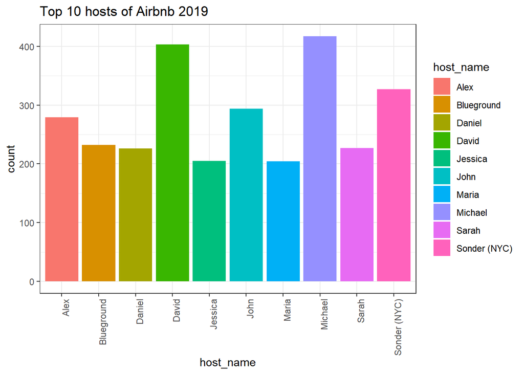

```r
ggplot(Top_10_Hosts_df, aes(x = host_name, y = count, fill = host_name)) +
  geom_bar(stat = 'identity') +
  labs(title = 'Top 10 hosts of Airbnb 2019') +
  theme_bw() +
  theme(axis.text.x = element_text(angle = 90, hjust = 1))
```

## Now, let’s find our the top 10 areas.

```r
Top_10_Areas <- head(sort(table(Airbnb$neighbourhood), decreasing = TRUE), 10)
Top_10_Areas
```

```
##
##       Williamsburg Bedford-Stuyvesant             Harlem           Bushwick
##               3920               3714               2658               2465
##    Upper West Side     Hell's Kitchen       East Village    Upper East Side
##               1971               1958               1853               1798
##      Crown Heights            Midtown
##               1564               1545
```

## Converting Top_10_Areas into dataframe so that we can visualize.

```r
Top_10_Areas <- as.data.frame(Top_10_Areas)
Top_10_Areas
```

```
##                  Var1 Freq
## 1        Williamsburg 3920
## 2  Bedford-Stuyvesant 3714
## 3              Harlem 2658
## 4            Bushwick 2465
## 5     Upper West Side 1971
## 6      Hell's Kitchen 1958
## 7        East Village 1853
## 8     Upper East Side 1798
## 9       Crown Heights 1564
## 10            Midtown 1545
```

Let’s visualize it.

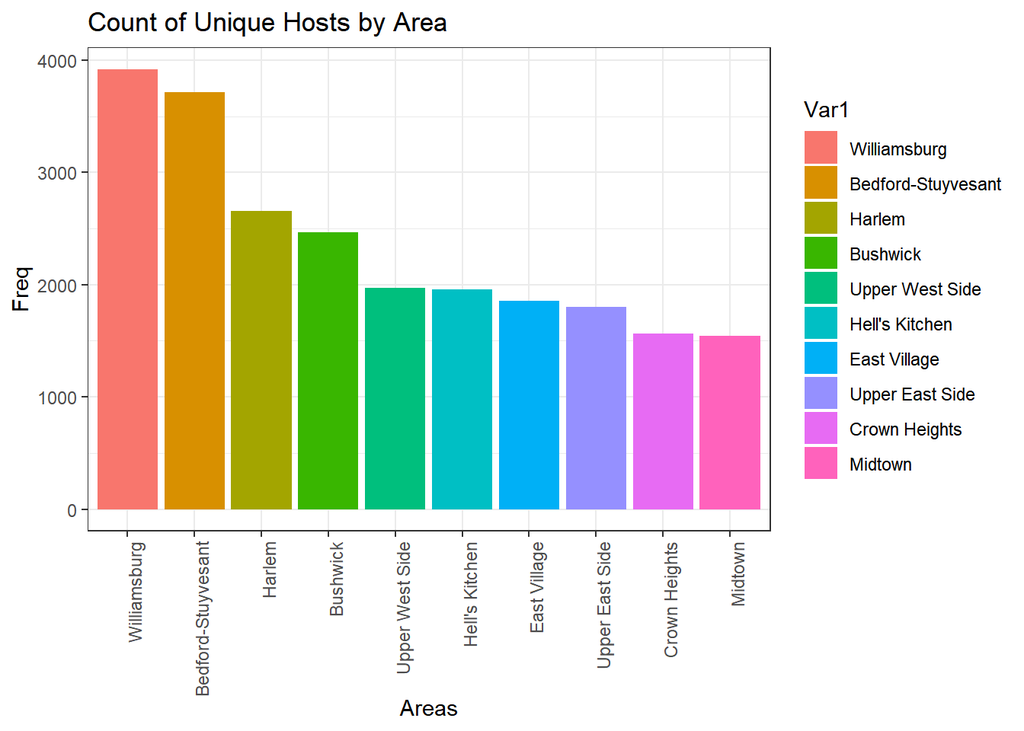

```r
ggplot(Top_10_Areas, aes(x = Var1, y = Freq, fill = Var1)) +
  geom_bar(stat = 'identity') +
  labs(x = "Areas") +
  ggtitle("Count of Unique Hosts by Area") +
  theme_bw() +
  theme(axis.text.x = element_text(angle = 90, hjust = 1))
```

## Let’s see which type of rooms does more business in different areas.

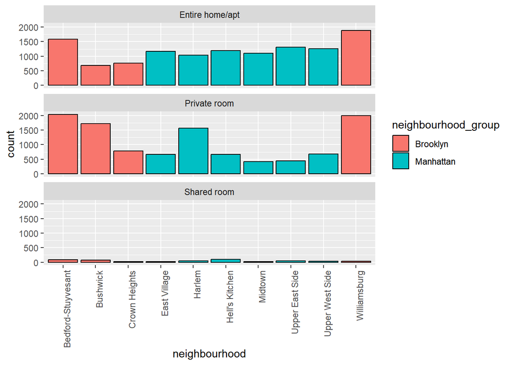

```r
sub_7 <- subset(Airbnb, neighbourhood %in% c('Williamsburg','Bedford-Stuyvesant','Harlem','Bushwick',
                                    'Upper West Side','Hell\'s Kitchen','East Village',
                                    'Upper East Side','Crown Heights','Midtown'))

viz_3 <- ggplot(sub_7, aes(x = neighbourhood, fill = neighbourhood_group)) +
  geom_bar(col = 'black') +
  facet_wrap(~ room_type, ncol = 1) +
  theme(axis.text.x = element_text(angle = 90, hjust = 1))

print(viz_3)
```

## Let’s see if longitude and latitude have anything to tell.

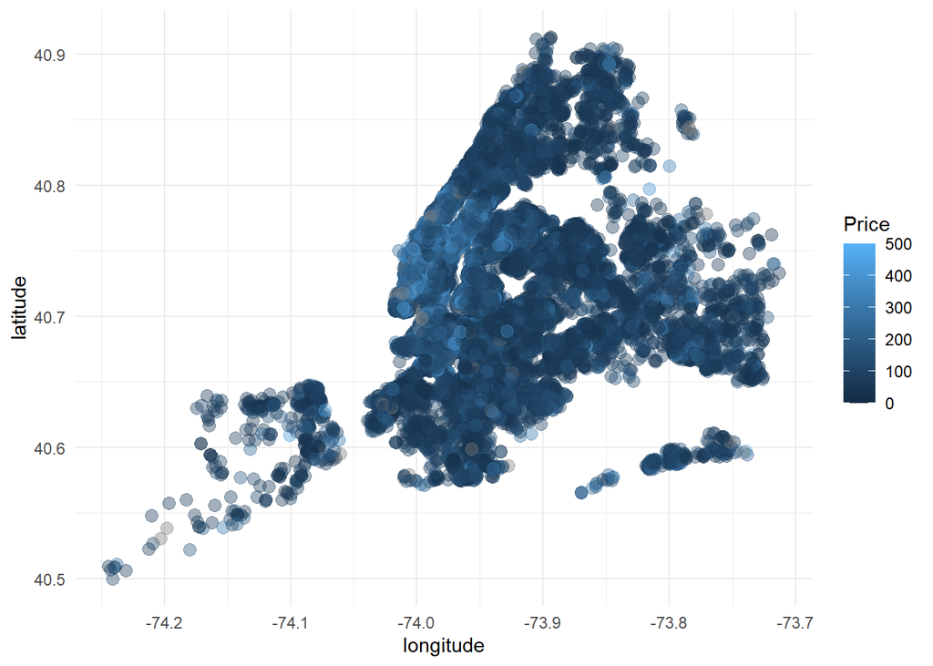

```r
ggplot(Airbnb, aes(x = longitude, y = latitude, color = price)) +
  geom_point(size = 3, alpha = 0.4) +
  scale_color_continuous(limits = c(0, 500)) +
  labs(color = "Price") +
  theme_minimal() +
  theme(legend.position = "right")
```

## Let’s see the count of unique host from different locations.

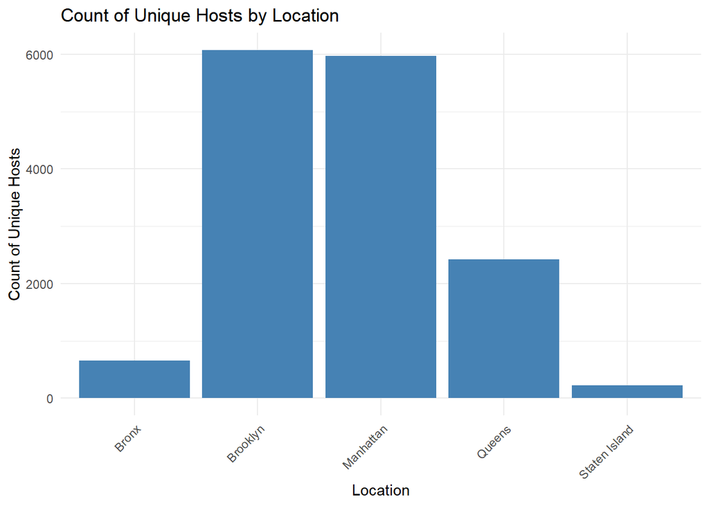

```r
count_data <- data.frame(neighbourhood_group = unique(Airbnb$neighbourhood_group),
                         unique_hosts = sapply(unique(Airbnb$neighbourhood_group),
                                               function(loc) length(unique(Airbnb$host_name[Airbnb$neighbourhood_group == loc]))))
ggplot(count_data, aes(x = neighbourhood_group, y = unique_hosts)) +
  geom_bar(stat = "identity", fill = "steelblue") +
  labs(x = "Location", y = "Count of Unique Hosts") +
  ggtitle("Count of Unique Hosts by Location") +
  theme_minimal() +
  theme(axis.text.x = element_text(angle = 45, hjust = 1))
```

## Let’s see the total price earned by different locations.

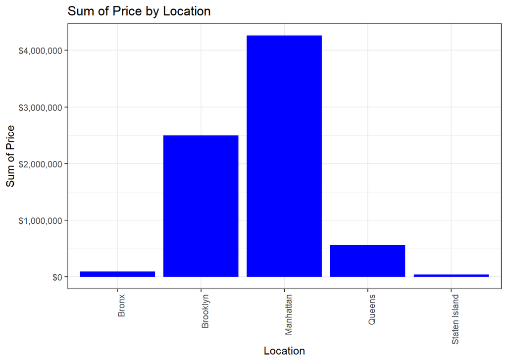

```r
ggplot(Airbnb, aes(x = neighbourhood_group, y = price)) +
  geom_bar(stat = "identity", fill = "blue") +
  labs(title = "Sum of Price by Location", x = "Location", y = "Sum of Price") +
  scale_y_continuous(labels = dollar_format(prefix = "$", big.mark = ",", decimal.mark = ".", suffix = "")) +
  theme_bw() +
  theme(axis.text.x = element_text(angle = 90, hjust = 1))
```

## Let’s see the total reviews got by differnt locations.

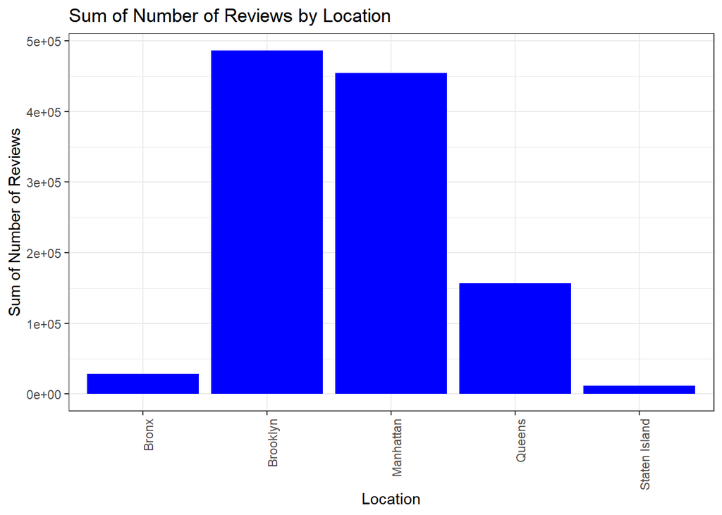

```r
ggplot(Airbnb, aes(x = neighbourhood_group, y = number_of_reviews)) +
  geom_bar(stat = "identity", fill = "blue") +
  labs(title = "Sum of Number of Reviews by Location", x = "Location", y = "Sum of Number of Reviews") +
  theme_bw() +
  theme(axis.text.x = element_text(angle = 90, hjust = 1))
```

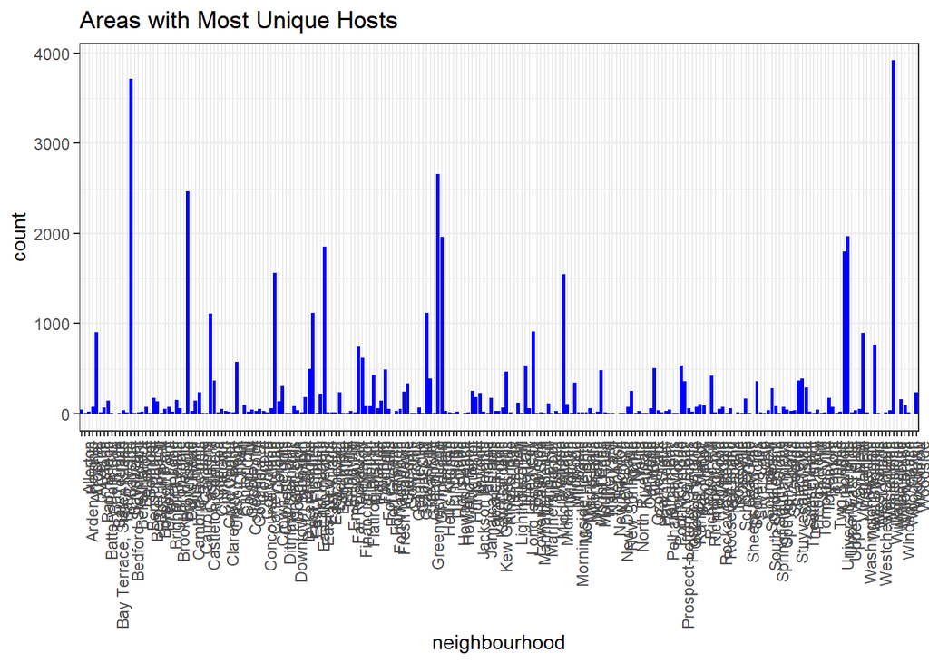

```r
ggplot(Airbnb, aes(x = neighbourhood, y = ..count..)) +
  geom_bar(stat = "count", fill = "blue") +
  labs(title = "Areas with Most Unique Hosts") +
  theme_bw() +
  theme(axis.text.x = element_text(angle = 90, hjust = 1))
```